# Rで解析練習 解答編

Tomoki Nishikawa

2021-02-18

# 1 概要

- レセプトデータ解析で使う基礎的なテクニックを集めた練習問題
  - 下に行くほど難しいです
  - 新4年生がやることを想定だが、5,6年生でも勉強になるはず

# 2 準備(パッケージ読み込み)

- 以下のコードを事前に実行しといてください

```r
library(tidyverse); library(magrittr); library(data.table); library(lubridate)
```

# 3 データ読み込み

- 「data」フォルダ内の以下3つのcsvファイルを読み込んでください
  - patient.csv
  - disease.csv
  - drug.csv

```r
DATAPATH <- "./data/"
patient <- fread(paste0(DATAPATH, "patient.csv"), data.table = FALSE)
disease <- fread(paste0(DATAPATH, "disease.csv"), data.table = FALSE)
drug <- fread(paste0(DATAPATH, "drug.csv"), data.table = FALSE)
```

# 4 並べ替え

```r
patient2 <- patient %>%
  arrange(start_date)
```

# 5 フィルタ

- patientのうちgenderが「F」である人を抜き出し、patient_femaleというデータフレームに代入してください

```r
patient_female <- patient %>%
  filter(gender == "F")
```

# 6 集計

- patientのageの平均値を、genderごとに算出してください
- 結果の例↓

```r
patient %>%
  group_by(gender) %>%
  summarise(mean_age = mean(age), .groups = "drop")
```

```
## # A tibble: 2 x 2
##   gender mean_age
## * <chr>     <dbl>
## 1 F          48.2
## 2 M          45.2
```

# 7 列名変更

- drugのdate列をdrug_dateに変更し、drugを上書きしてください
- diseaseのdate列をdisease_dateに変更し、diseaseを上書きしてください

```r
drug <- drug %>%
  rename(drug_date = date)
disease <- disease %>%
  rename(disease_date = date)

# 以下別解
drug <- drug %>%
  set_colnames(c("id", "drug_date", "atccode", "dose_amount"))
disease <- disease %>%
  set_colnames(c("id", "disease_date", "icd10code"))
```

# 8 重複削除

- drugのうち、各患者の初回処方日の行のみ抽出してdrug_firstというデータフレームに代入してください

```r
drug_first <- drug %>%
  arrange(id, drug_date) %>%
  distinct(id, .keep_all = TRUE)

# 別解
drug_first <- drug %>%
  arrange(id, drug_date) %>%
  group_by(id) %>%
  filter(row_number() == 1) %>%
  ungroup()
```

# 9 結合 & 集計再び

- idをキーに、drugの横にpatientのgender列を結合して、drug_genderというデータフレームに代入してください

```r
drug_gender <- drug %>%
  left_join(patient %>% select(id, gender), "id")
```

- 次に、genderごとのdose_amount合計、平均、中央値、最大、最小を算出してください

```r
drug_gender %>%
  group_by(gender) %>%
  summarise(sum_dose = sum(dose_amount),
            mean_dose = mean(dose_amount),
            median_dose = median(dose_amount),
            max_dose = max(dose_amount),
            min_dose = min(dose_amount))
```

```
## # A tibble: 2 x 6
##   gender sum_dose mean_dose median_dose max_dose min_dose
## * <chr>     <int>     <dbl>       <int>    <int>    <int>
## 1 F          5956      50.9          51       90        3
## 2 M         11218      46.9          49       90        1
```

# 10 部分一致によるフィルタ

- drugのうち、atccodeに「C」という文字が含まれる行を抽出しdrug_cというデータフレームに代入してください

```r
drug_c <- drug %>%
  filter(str_detect(atccode, "C"))
```

# 11 列作成

- diseaseに新しい列「event」を作成します。eventには、icd10codeが「C03」である場合は1を、違う場合は0を代入してください(characterで)。列を追加したデータフレームをdisease_eventという名前に代入してください。

```r
disease_event <- disease %>%
  mutate(event = if_else(icd10code == "C03", "1", "0"))
```

# 12 観察期間算出

- まずdisease_eventの「event」列が1の行のみをフィルタし、重複削除によってidごとに最も早いeventのみを残してください。これをdisease_eventに上書きしてください。

```r
disease_event <- disease_event %>%
  filter(event == "1") %>%
  arrange(id, disease_date) %>%
  distinct(id, .keep_all = TRUE)
```

- idをキーに、patientの右にdisease_eventを結合したものをpatient_dis_eventというデータフレームに代入してください。
- 更にpatient_dis_eventの「event」列のうち欠損(NA)であるところにcharacterで0を入れ、patient_dis_eventを上書きしてください。

```r
patient_dis_event <- patient %>%
  left_join(disease_event, "id") %>%
  mutate(event = if_else(is.na(event), "0", event))
```

```r
patient_time <- patient_dis_event %>%
  mutate(across(c(start_date, end_date, disease_date), ~ymd(.))) %>%
  mutate(time = if_else(event == "1",
                        disease_date - start_date,
                        end_date - start_date)) %>%
  mutate(time = as.numeric(time)) # そのままでもいいが一応数値として扱う
```

# 13 人年法

- patient_timeより、genderごとに1000人年あたりのイベント数を算出する。
  - 1000人年当たりの発生率 = 総イベント数 / 総観察期間(日) × 365 × 1000
  - genderごとに総観察期間と総イベント数を算出し、上の式に沿って計算

```r
patient_time %>%
  group_by(gender) %>%
  summarise(event_total = sum(event == "1"),
            time_total = sum(time),
            `rate_per_thousand` = event_total * 365 * 1000 / time_total)
```

```
## # A tibble: 2 x 4
##   gender event_total time_total rate_per_thousand
## * <chr>        <int>      <dbl>             <dbl>
## 1 F                2       4109             178.
## 2 M                2      11064              66.0
```

# 14 プロット(自力でできる必要はない)

- patient_timeのgenderごとに、time, eventを用いてカプランマイヤー(Kaplan-Meier)曲線を書いてみてください。
  - survival, survminerを使います。
  - eventをnumericにする必要あり

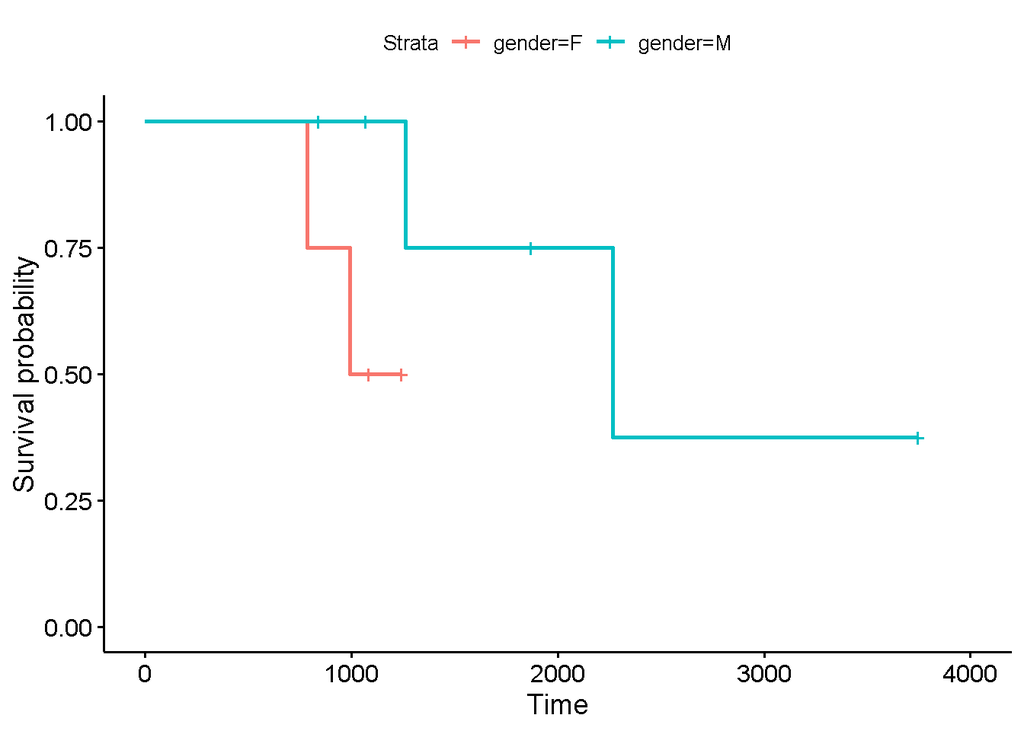

```r
library(survival); library(survminer)

survfit(Surv(time, as.numeric(event)) ~ gender, data = patient_time) %>%
  ggsurvplot(data = patient_time)
```